# Community Contribution

Klyment Mamykin (km2770)

## Ask A Manager Salary Survey 2019 dataset

A survey posted in a popular blog “Ask A Manager”https://www.askamanager.org asked the readers to anonymously fill out how much money they were making. Since the [blog post](https://www.askamanager.org/2019/04/how-much-money-do-you-make-3.html) was published, it went viral, and 31407 people filled out the survey. A Google sheet was used to aggregate the responses, located [here](https://docs.google.com/spreadsheets/d/1rGCKXIKt-7l5gX06NAwO3pjqEHh-oPXtB8ihkp0vGWo). The data is interesting but the analysis of this dataset is made difficult by the freeform entered data, with little standartization on the values allowed (to minimize the friciton of filling out the form).

The goal for this project is to clean up the data and make it available for community for further analysis. The project started as a Community Contribution assignment for [Exploratory Data Analysis & Visualization](https://edav.info/) course at Columbia University Data Science program.

## Obtaining the dataset

Version 1 of the cleaned up dataset is located at (https://github.com/kmamykin/askamanager_salary_survey/raw/master/data/v1/Ask-A-Manager-Salary-Survey-2019.csv)

```r
salary_survey <- readr::read_csv("https://github.com/kmamykin/askamanager_salary_survey/raw/master/data/v1/Ask-A-Manager-Salary-Survey-2019.csv")
```

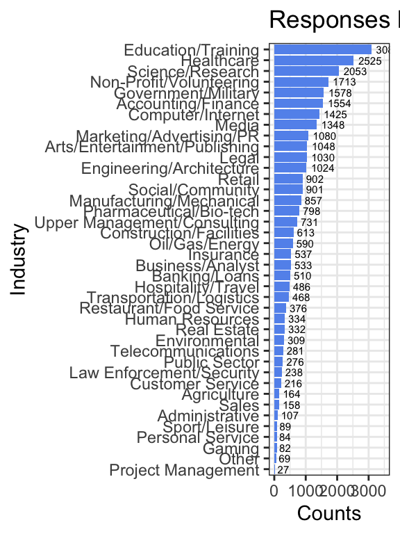

```r
salary_survey %>%
  drop_na(Industry) %>%
  group_by(Industry) %>%
  summarise(Freq = n()) %>%
  ggplot(aes(x=fct_reorder(Industry, Freq), y=Freq)) +
  geom_bar(stat = "identity", fill = "cornflowerblue") +
  geom_text(aes(label = Freq), position = position_dodge(width = 1), hjust = -0.2, size = 2) +
  coord_flip() +
  ylim(0, 3500) +
  xlab("Industry") +
  ylab("Counts") +
  ggtitle("Responses by Industry") +
  theme_bw()
```

## Description of fields

- `Timestamp` - timestamp of the submittd response
- `Age` - age bracket: “35-44” “25-34” “18-24” “25-34”…, one of the few fields that was a choice and did not need a cleanup
- `Industry` - one of the values mentioned in https://www.webspidermount.com/features/generic-job-taxonomy/ . While there are many different industry classification taxonomies, this particular taxonomy looked simple and targeted for a job search domain. The values were normalized based on `Industry (Original)` using a ML model (see below)
- `JobTitle` - user entered field, clustered to remove small variations (e.g. “sr.engineer” vs “Sr Engineer”). There is still too much variation and this field need more normalization work.
- `Currency` - currency of the Base pay
- `City`, `State`, `Country` - this vas normalized from `Location (Original)` field by calling Google Locations API and further manual tweaking with OpenRefine
- `Location` - normalized location in format “Nashville, TN, USA”. Only USA, AUstralia, Canada have states in this dataset, for other countries it looks like “Manchester, UK”
- `Experience` - e.g. “11 - 20 years”,“8 - 10 years” etc. Also did not need normalization
- `Base` - base salary. This is the main metric. A lot of parsing and regex transforms went to this field to extract the numbers from freeform `AnnualSalary (Original)`. Extra perks got separated into `Extras` field, where it was detected that the compensation was at hourly rate, the rate was extracted to `HourlyRate` and the `Base` was calculated with `HourlyRate` * 1650 hours/year (this is a big assumption here)
- `HourlyRate` - extracted hourly rate from `AnnualSalary (Original)`
- `Extras` - extracted extra perks/comments from `AnnualSalary (Original)`
- `Notes` - user provided notes
- `AnnualSalary (Original)` - original field
- `Location (Original)` - original field
- `JobTitle (Original)` - original field
- `Industry (Original)` - original field
- `Industry (Clustered)` - `Industry (Original)` clustered with OpenRefine to remove small variations of spelling/capitalization

```r
str(salary_survey)
```

```
## Classes 'spec_tbl_df', 'tbl_df', 'tbl' and 'data.frame': 31381 obs. of  20 variables:
##  $ Timestamp              : chr  "4/24/2019 11:43:21" "4/24/2019 11:43:26" "4/24/2019 11:43:27" "4/24/2019 11:43:27" ...
##  $ Age                    : chr  "35-44" "25-34" "18-24" "25-34" ...
##  $ Industry               : chr  "Government/Military" "Environmental" "Science/Research" "Pharmaceutical/Bio-tech" ...
##  $ JobTitle               : chr  "Talent Management Asst. Director" "Director, Operations" "Market Research Analyst" "Senior Scientist" ...
##  $ Currency               : chr  "USD" "USD" "USD" "GBP" ...
##  $ City                   : chr  "Nashville" "Madison" "Las Vegas" "Cardiff" ...
##  $ State                  : chr  "TN" "WI" "NV" NA ...
##  $ Country                : chr  "USA" "USA" "USA" "UK" ...
##  $ Location               : chr  "Nashville, TN, USA" "Madison, WI, USA" "Las Vegas, NV, USA" "Cardiff, UK" ...
##  $ Experience             : chr  "11 - 20 years" "8 - 10 years" "2 - 4 years" "5 - 7 years" ...
##  $ Base                   : num  75000 65000 36330 34600 55000 ...
##  $ HourlyRate             : num  NA NA NA NA NA NA NA NA NA NA ...
##  $ Extras                 : chr  NA NA NA NA ...
##  $ Notes                  : chr  NA NA NA NA ...
##  $ AnnualSalary (Original): chr  "75000" "65,000" "36,330" "34600" ...
##  $ AnnualSalary           : chr  "75000" "65000" "36330" "34600" ...
##  $ Location (Original)    : chr  "Nashville, TN" "Madison, Wi" "Las Vegas, NV" "Cardiff, UK" ...
##  $ JobTitle (Original)    : chr  "Talent Management Asst. Director" "Operations Director" "Market Research Assistant" "Senior Scientist" ...
##  $ Industry (Original)    : chr  "Government" "Environmental nonprofit" "Market Research" "Biotechnology" ...
##  $ Industry (Clustered)   : chr  "Government" "Environmental non-profit" "Market Research" "Biotechnology" ...
##  - attr(*, "spec")=
##   .. cols(
##   ..   Timestamp = col_character(),
##   ..   Age = col_character(),
##   ..   Industry = col_character(),
##   ..   JobTitle = col_character(),
##   ..   Currency = col_character(),
##   ..   City = col_character(),
##   ..   State = col_character(),
##   ..   Country = col_character(),
##   ..   Location = col_character(),
##   ..   Experience = col_character(),
##   ..   Base = col_double(),
##   ..   HourlyRate = col_double(),
##   ..   Extras = col_character(),
##   ..   Notes = col_character(),
##   ..   `AnnualSalary (Original)` = col_character(),
##   ..   AnnualSalary = col_character(),
##   ..   `Location (Original)` = col_character(),
##   ..   `JobTitle (Original)` = col_character(),
##   ..   `Industry (Original)` = col_character(),
##   ..   `Industry (Clustered)` = col_character()
##   .. )
```

## Data cleanup process

[OpenRefine](http://openrefine.org/) was used for most of the heavy lifting of data massaging.

> OpenRefine (previously Google Refine) is a powerful tool for working with messy data: cleaning it; transforming it from one format into another; and extending it with web services and external data.

### Industry classification

The initial attempt to manually cleanup the original `Industry (Original)` field was taking to long, and in the middle I decided to change the taxonomy. To automate this process a simple machine learning model was used to classify user entered industry into a target set of industry taxonomy values.

For both sets of the target industries and the input industries I scraped Google search result and the resulting organic web sites, creating a rich text document describing each target industry as well as each user input industry. Using a simple bag of words document representation and KNN classifier (k=1), each input industry was classified into the target industry.

### Job Title classification

TODO - transform the freeform entered job titles into `Seniority` field and `Job Area` field, e.g. “Senior Data Scientist” would be transformed to “Senior” seniority and “Data Science” job area.

### Contributing

Contributions are welcome! If you notice a error in the dataset, or would like to add further cleanup - please follow this process:

1. Download the dataset and create a project in OpenRefine.
2. Perform desired data operations.
3. Switch to “Undo/Redo” tab and “Extract…” transformation file in JSON.
4. Submit your changes in a Pull Request with transformation file attached.

[figure not shown]